# homework_8

b06208016楊鎧綾

November 2, 2018

## 10.12

### a

confidence interval is between(0.47-0.03,0.47+0.03)=**(0.44,0.5)**

### b

```r
prop.test(x=0.47*1100,n=1100,alternative = "two.sided",conf.level = 0.95)
```

```
##
##  1-sample proportions test with continuity correction
##
## data:  0.47 * 1100 out of 1100, null probability 0.5
## X-squared = 3.8409, df = 1, p-value = 0.05002
## alternative hypothesis: true p is not equal to 0.5
## 95 percent confidence interval:
##  0.4402099 0.5000021
## sample estimates:
##    p
## 0.47
```

the confidence interval by calculate is(0.4402099,0.5000021)  
此題的margion error 估計是以conservative 的方式(把計算標準誤的phat當作0.5)，因為0.47和0.5還算接近因此使用conservative的方式和精準地計算出來的信賴區間不會相差太多，不過還是會略大一點  
**the confidence interval under 95% is(0.44,0.50),which means 95% of the selected population would be in the interval , or the probability the population will be in the interval is 95%**

## 10.22

### a

the phat is **0.3**,which is the sample proportion that answered less strict

### b

```r
se=sqrt(0.3*0.7/439);se
```

```
## [1] 0.02187144
```

**the standard error is 0.02187144**

### c

#### by calculate

```r
0.3+1.96*se
```

```
## [1] 0.342868
```

```r
0.3-1.96*se
```

```
## [1] 0.257132
```

#### by code

```r
prop.test(x=0.3*439,n=439,alternative = "two.sided",conf.level = 0.95)
```

```
##
##  1-sample proportions test with continuity correction
##
## data:  0.3 * 439 out of 439, null probability 0.5
## X-squared = 69.442, df = 1, p-value < 2.2e-16
## alternative hypothesis: true p is not equal to 0.5
## 95 percent confidence interval:
##  0.2579357 0.3456258
## sample estimates:
##   p
## 0.3
```

the confidence by calculate is(0.257132,0.342868)  
and by code is(0.2579357,0.3456258)  
which are approximately the same

### d

**the confidence interval for the population proportion means 95% of the selected population is between 25.7% and 34.3% , or the probability the population will be in the interval is 95%**

## 10.28

### a

```r
prop.test(x=0.57*1006,n=1006,alternative = "two.sided",conf.level = 0.95)
```

```
##
##  1-sample proportions test with continuity correction
##
## data:  0.57 * 1006 out of 1006, null probability 0.5
## X-squared = 19.439, df = 1, p-value = 1.039e-05
## alternative hypothesis: true p is not equal to 0.5
## 95 percent confidence interval:
##  0.5386985 0.6007603
## sample estimates:
##    p
## 0.57
```

**the confidence interval under 95% is(0.5386985,0.6007603)**

### b

**because the interval is all above 50%, so we can infer that in 2009 more than half of all Americans thought that abortions should be legal only under certain circumstances**

### c

```r
prop.test(x=0.18*1006,n=1006,alternative = "two.sided",conf.level = 0.95)
```

```
##
##  1-sample proportions test with continuity correction
##
## data:  0.18 * 1006 out of 1006, null probability 0.5
## X-squared = 410.78, df = 1, p-value < 2.2e-16
## alternative hypothesis: true p is not equal to 0.5
## 95 percent confidence interval:
##  0.1570209 0.2054645
## sample estimates:
##    p
## 0.18
```

**the confidence interval under 95% is(0.1570209,0.2054645)**

## 10.48

### a

```r
1/sqrt(501)
```

```
## [1] 0.04467671
```

```r
Z=0.05*sqrt(501)/0.5
Z
```

```
## [1] 2.238303
```

```r
pn=pnorm(Z, mean = 0, sd = 1)
pn-(1-pn)
```

```
## [1] 0.9747987
```

這一題若直接用信心水準95%(multiplier=2的狀況下)且phat來計算會得到margion error 為0.44而不是0.5，因此要去找他是在什麼信賴區間下假設phat為0.5來求得，由程式碼可知是在97.5的信賴區間下求取，不過後面幾小題是寫他是在信心水準95%下，因此後面還是將他當成是在信心水準95%下  
**the margion might calculate in the condition of phat=0.5 under 97.5% confidence level**

### b

**the confidence interval under 95% is(0.49,0.59),which means 95% of the selected population would be in the interval , or the probability the population will be in the interval is 95%**

### c

```r
prop.test(x=0.54*501,n=501,alternative = "two.sided",conf.level = 0.95)
```

```
##
##  1-sample proportions test with continuity correction
##
## data:  0.54 * 501 out of 501, null probability 0.5
## X-squared = 3.0484, df = 1, p-value = 0.08082
## alternative hypothesis: true p is not equal to 0.5
## 95 percent confidence interval:
##  0.4952216 0.5841558
## sample estimates:
##    p
## 0.54
```

**the confidence interval under 95% is(0.4952216,0.5841558),which means 95% of the selected population would be in the interval , or the probability the population will be in the interval is 95%**

### d

**the confidence interval under 95% of given margin error is(0,0.1),which means 95% of the selected population would be in the interval , or the probability the population will be in the interval is 95%**

```r
prop.test(x=0.05*501,n=501,alternative = "two.sided",conf.level = 0.95)
```

```
##
##  1-sample proportions test with continuity correction
##
## data:  0.05 * 501 out of 501, null probability 0.5
## X-squared = 404.01, df = 1, p-value < 2.2e-16
## alternative hypothesis: true p is not equal to 0.5
## 95 percent confidence interval:
##  0.03329286 0.07390659
## sample estimates:
##    p
## 0.05
```

**the confidence interval under 95% of compute is(0.03329286,0.07390659),which means 95% of the selected population would be in the interval , or the probability the population will be in the interval is 95%**

### e

**because the given margin error is in the condition of phat=0.5,the phat of d is 0.05 which is far from 0.5;and the phat of bc is 0.54 which is around 0.5.so the interval is more colsly in part b and c**

## 10.54

### a

```r
prop.test(x=c(85,24),n=c(1105,1379),alternative = "two.sided",conf.level = 0.95)
```

```
##
##  2-sample test for equality of proportions with continuity
##  correction
##
## data:  c(85, 24) out of c(1105, 1379)
## X-squared = 50.388, df = 1, p-value = 1.262e-12
## alternative hypothesis: two.sided
## 95 percent confidence interval:
##  0.04154351 0.07749481
## sample estimates:
##     prop 1     prop 2
## 0.07692308 0.01740392
```

**the confidence interval under 95% is (0.04154351,0.07749481)**

### b

**因為信賴區間沒有涵蓋0，所以nonsnorer 和snorer罹患心臟病是有差別的**

## 10.66

### a

**因為兩個信賴區間沒有交集，因此可以說男生和女生對於罹患此疾病的機率是有差別的**

### b

the mean of phat1 is (0.11+0.17)/2=0.14;  
the mean of phat2 is (0.04+0.08)/2=0.06

```r
prop.test(x=c(0.14*524,0.06*542),n=c(524,542),alternative = "two.sided",conf.level = 0.95)
```

```
##
##  2-sample test for equality of proportions with continuity
##  correction
##
## data:  c(0.14 * 524, 0.06 * 542) out of c(524, 542)
## X-squared = 18.176, df = 1, p-value = 2.014e-05
## alternative hypothesis: two.sided
## 95 percent confidence interval:
##  0.04231276 0.11768724
## sample estimates:
## prop 1 prop 2
##   0.14   0.06
```

**the confidence interval under 95% of the difference is(0.04231276,0.11768724)**

### c

**因為信賴區間沒有涵蓋0，而且都大於0，可以說男生和女生罹患此疾病是有差別的，而且男生更容易**

## r studio

```r
Prop_CI = function(n1,n2,p1, p2, confd) {

  all.phat = c()
  for (i in 1:10000) {
    phat1 = sum(sample(c(0,1), n1, replace = T, prob = c(1-p1,p1)))/n1
    phat2 = sum(sample(c(0,1), n2, replace = T, prob = c(1-p2,p2)))/n2
    phat_d=phat1-phat2
    all.phat[i] = phat_d
  }

  all.phat = sort(all.phat)

  low.per = ceiling(((1-confd)/2)*10000)
  low.vlue = all.phat[low.per]
  high.per = ceiling((1-((1-confd)/2))*10000)
  high.vlue = all.phat[high.per]

  results = c(paste((1-confd)/2*100,"%"), paste((1-((1-confd)/2))*100,"%"), low.vlue, high.vlue)

  mean.p = mean(all.phat)
  sd.p = sd(all.phat)

  CI = list(CI = matrix(results, nrow = 2, byrow = T), mean = mean.p, sd = sd.p, all.phat=all.phat)

  return(CI)
}

CI=Prop_CI(1467,1575,915/1467,771/1575,0.95)
CI[1:3]
```

```
## $CI
##      [,1]                 [,2]
## [1,] "2.5 %"              "97.5 %"
## [2,] "0.0999668906417372" "0.168055312104392"
##
## $mean
## [1] 0.1340044
##
## $sd
## [1] 0.01757442
```

```r
# By calculation
n1 = 1467
n2=1575
p1=915/1467
p2 = 771/1575

z = qnorm((1-0.95)/2, lower.tail = F)
se = sqrt((p1*(1-p1)/n1)+(p2*(1-p2)/n2))

high.c = p1-p2 + z*se; high.c
```

```
## [1] 0.1691845
```

```r
low.c = p1-p2 - z*se; low.c
```

```
## [1] 0.09921164
```

在95%信心水準下，模擬的信賴區間是如程式所示,理論的的信賴區間是(0.0992,0.1692),兩者差距不大

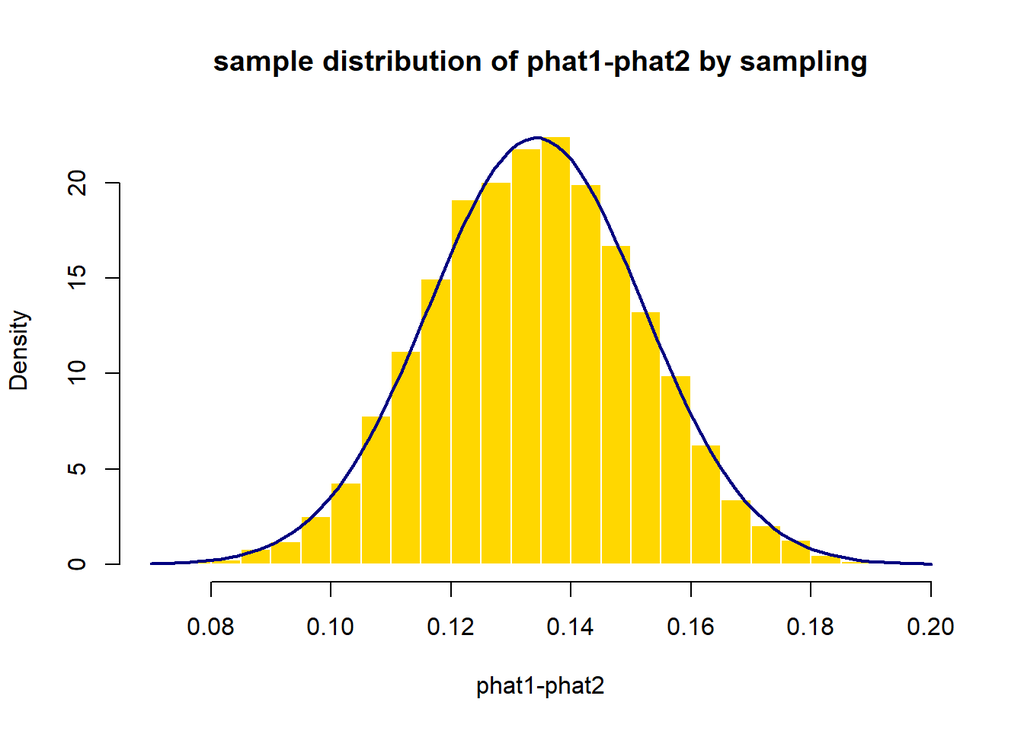

```r
#plot
#draw sample distribution
hist(CI[[4]],probability = T,breaks = 20,main="sample distribution of phat1-phat2 by sampling",xlab="phat1-phat2",col = "gold",border="white")
#加上理論的部分
curve(dnorm(x,p1-p2,se),add=T,col="navy",lwd=2)
```